# Type I and Type II Errors

Yuanting Lu

11/14/2025

### Do You Have Superpower

**Activity** If we randomly draw a card from a deck, do you have the superpower to know which one card is drawn? Use [the card app](https://shiny.yuanting.lu/cards) to find it out. Try 10 times and record your results.

|  | 1 | 2 | 3 | 4 | 5 | 6 | 7 | 8 | 9 | 10 |
| --- | --- | --- | --- | --- | --- | --- | --- | --- | --- | --- |
| Card Drawn |  |  |  |  |  |  |  |  |  |  |
| My Guess |  |  |  |  |  |  |  |  |  |  |

1. How many times did you get the card suit correct?
2. How many times did you get the card rank correct?
3. How many times did you get both the suit and the rank correct?
4. Does any of the results support that you have the superpower?

### Type I Error

A type I error occurs when we reject a true null hypothesis.

When the observations are in the tails (the gray areas), we believe they are unusual and we reject the null hypothesis. However, it is possible that the observations may fall in the tails by chance even though the chance is low.

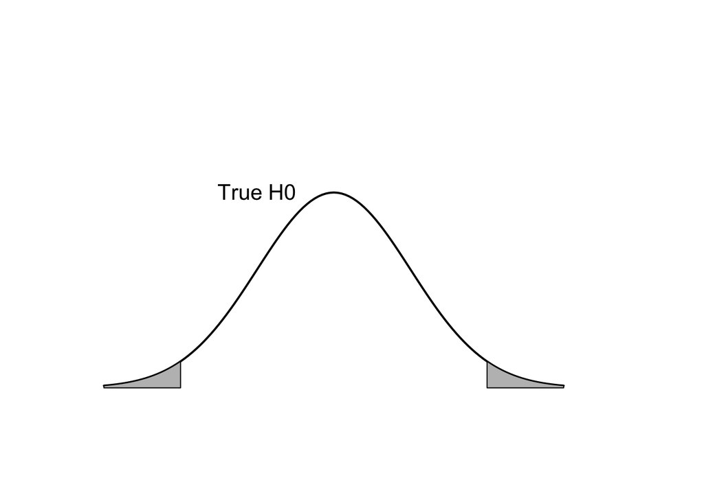

### Type II Error

A type II error occurs when we fail to reject a false null hypothesis.

When the observations are outside the tails (i.e., in the orange areas), we believe they are not unusual and we fail to reject the false null hypothesis.

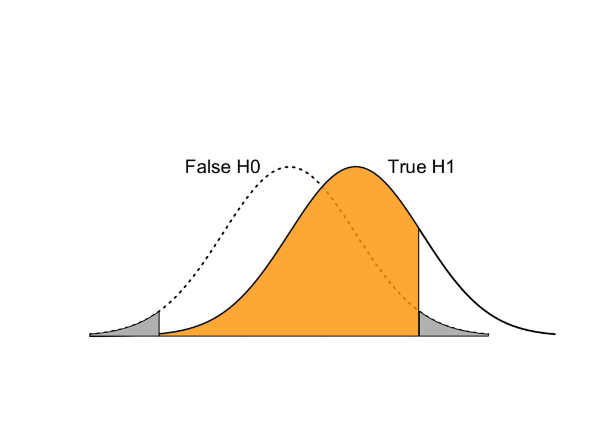

Use the applet below to explore the trade-off between Type I and Type II errors:

- Decreasing the Type I error increases the Type II error, and vice versa.
- The Type II error is also influenced by the difference between the parameter values in H<sub>0</sub> and H<sub>1</sub>.

[interactive chart not shown]